# Protocol variables

Since last version:

- replaced censored data by fill-in values
- replace `lm` by `survreg` beta estimation

To discuss:

- How to impute missing protocol vars (for now median imputed, before computing betas)
- Validate method
- Which data to include in the final sepages dataset?

Compounds included in document:

```
## [1] "MEPA_total" "ETPA_total" "BPA_total"  "OXBE_total" "TRCS_total"
```

# 1 Intro

In this document we analyse the link between the following protocol variables: **batch**, **defreeze time**, and **transport time** (with a special focus on batch) and the urinary levels of phenols with less than 30% samples < LOQ.

This analysis is limited to **pregnancy data**.

The life cycle of a urine sample in sepages is:

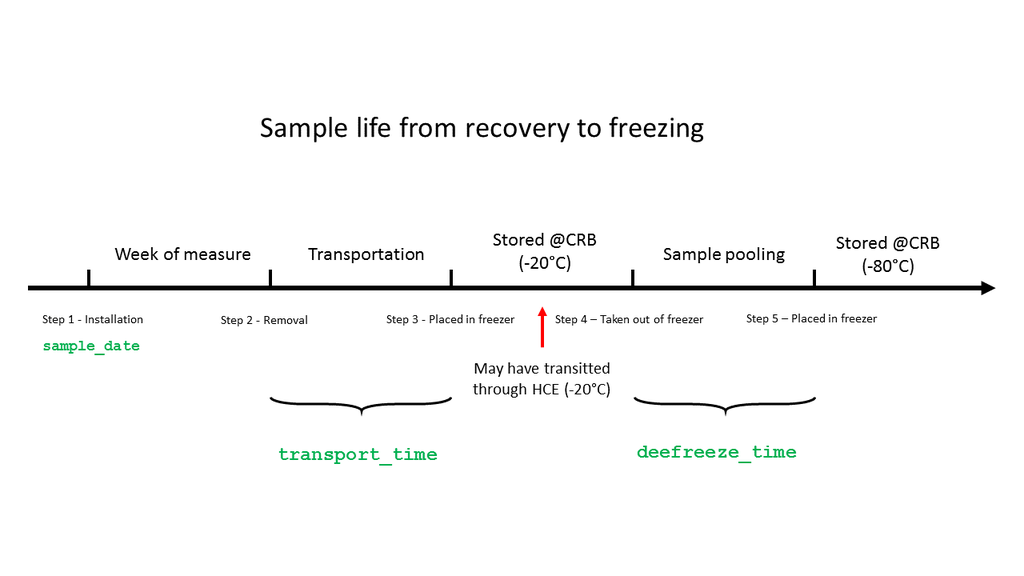

Sample process in sepages

# 2 Batch

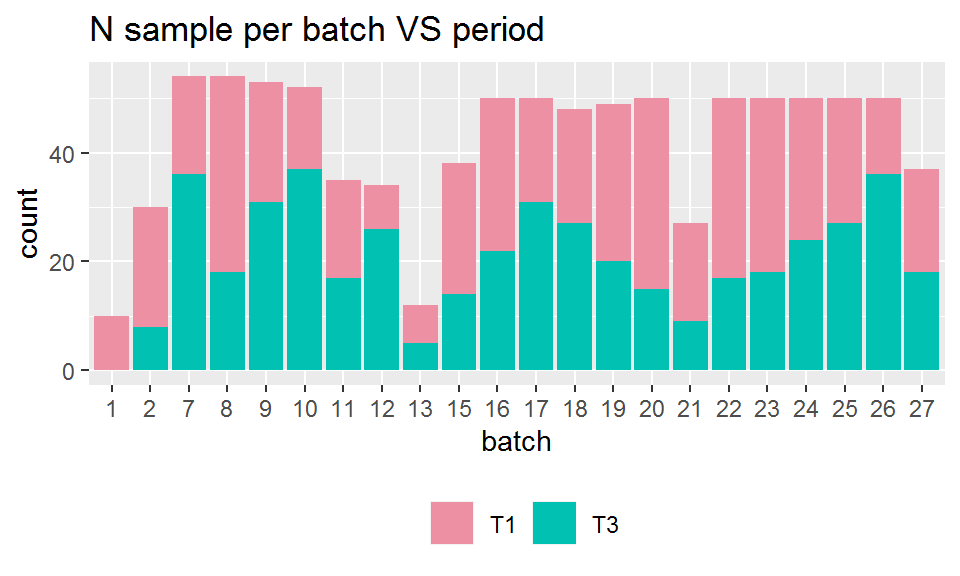

As we have previously seen there is a link between season on many compound levels it is interesting to note season variability between batches:

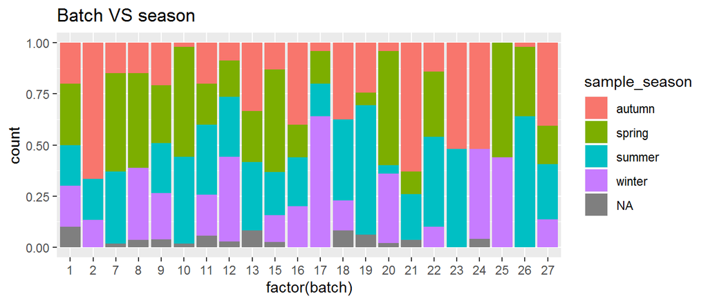

- Batch 17 used as reference because high N, high proportion of “winter” the reference category of the season variable and both present for both phthalates and phenols (code generalisability)

# 3 Defreeze time and transport time

Transport time was log transformed due to strong skewness and defreeze times were used as tertiles because of the outliers that were pulling the trends.

Values below or equal to zero were set to missing then all missing values were imputed to the median.

- N missing defreeze times: 58 / 933
- N missing transport times: 37 / 933

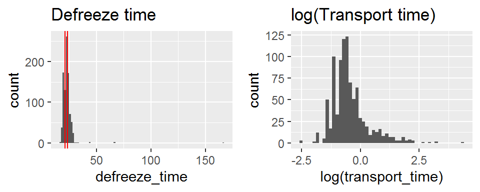